# Data visualization with ggplot2

### Example: Scales

Scales control how data values are mapped to visual properties such as colors, sizes, and axis positions.

While `aes()` defines **which variable** controls an aesthetic, `scale_*()` functions define **how its values are displayed**.

Common scale functions include:

- `scale_color_*()` – controls colors of points and lines
- `scale_fill_*()` – controls fill colors of bars and boxplots
- `scale_x_*()` and `scale_y_*()` – control axis scales
- `scale_size_*()` – controls point sizes

#### Changing colors

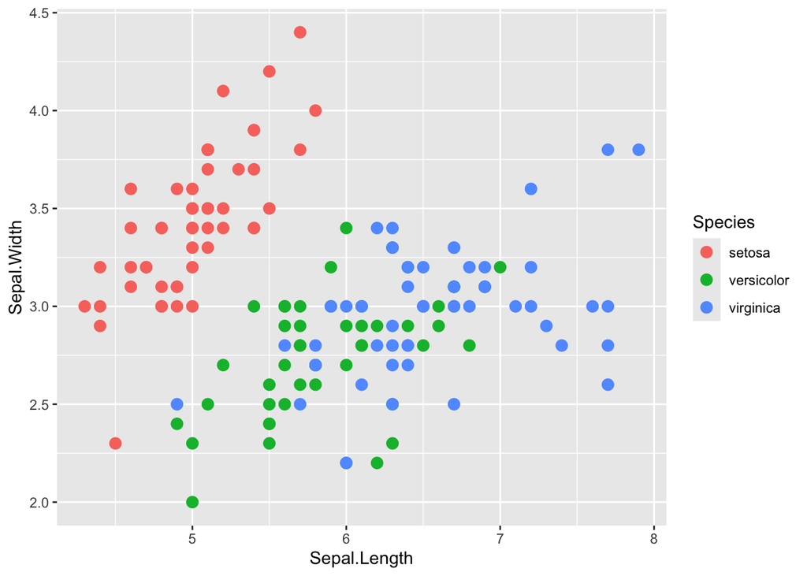

```r
# Default colors
p <- ggplot(iris, aes(x = Sepal.Length,
                      y = Sepal.Width,
                      color = Species)) +
  geom_point(size = 3)

p
```

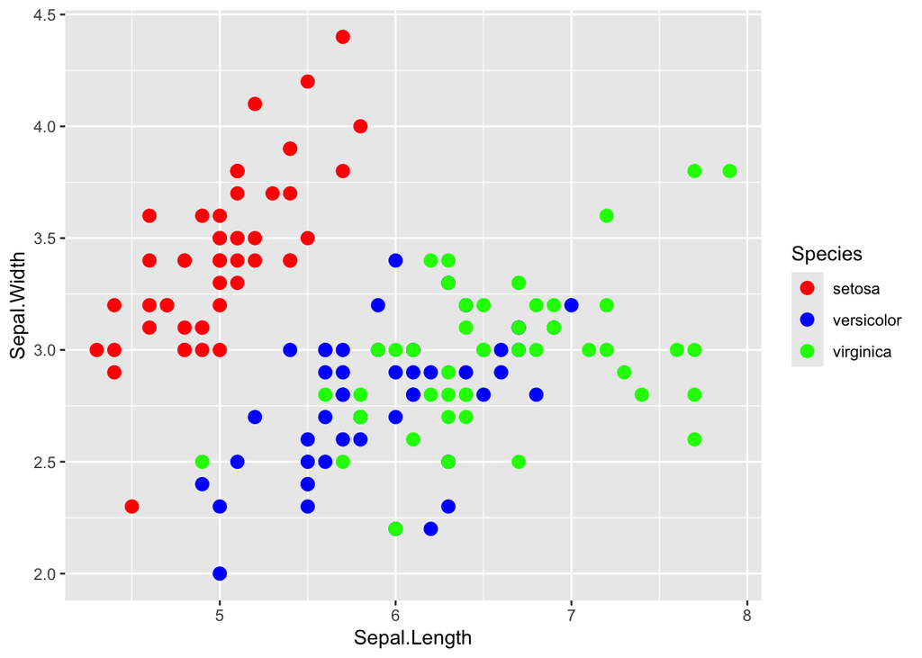

```r
# Manually specify colors
p + scale_color_manual(
  values = c("setosa" = "red",
             "versicolor" = "blue",
             "virginica" = "green")
)
```

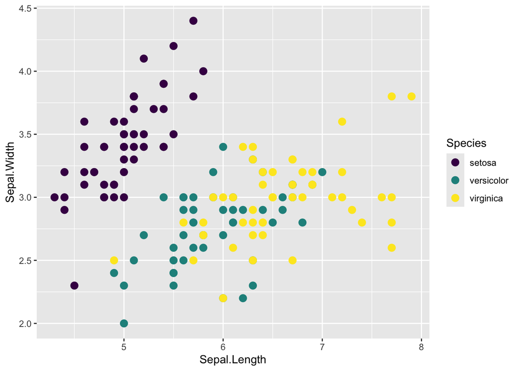

```r
# Use a predefined color palette
p + scale_color_viridis_d()
```

The `_d` suffix indicates a discrete scale, used for categorical variables. The `_c` suffix indicates a continuous scale, used for numerical variables.

#### Modifying axis scales

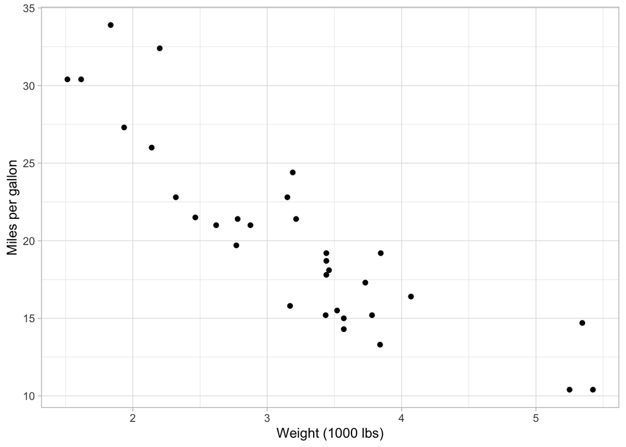

```r
ggplot(mtcars, aes(x = wt, y = mpg)) +
  geom_point() +
  scale_x_continuous(
    breaks = seq(1, 6, 1)
  ) +
  scale_y_continuous(
    breaks = seq(10, 35, 5)
  ) +
  labs(
    x = "Weight (1000 lbs)",
    y = "Miles per gallon"
  ) +
  theme_light()
```

We can also transform an axis using a logarithmic scale:

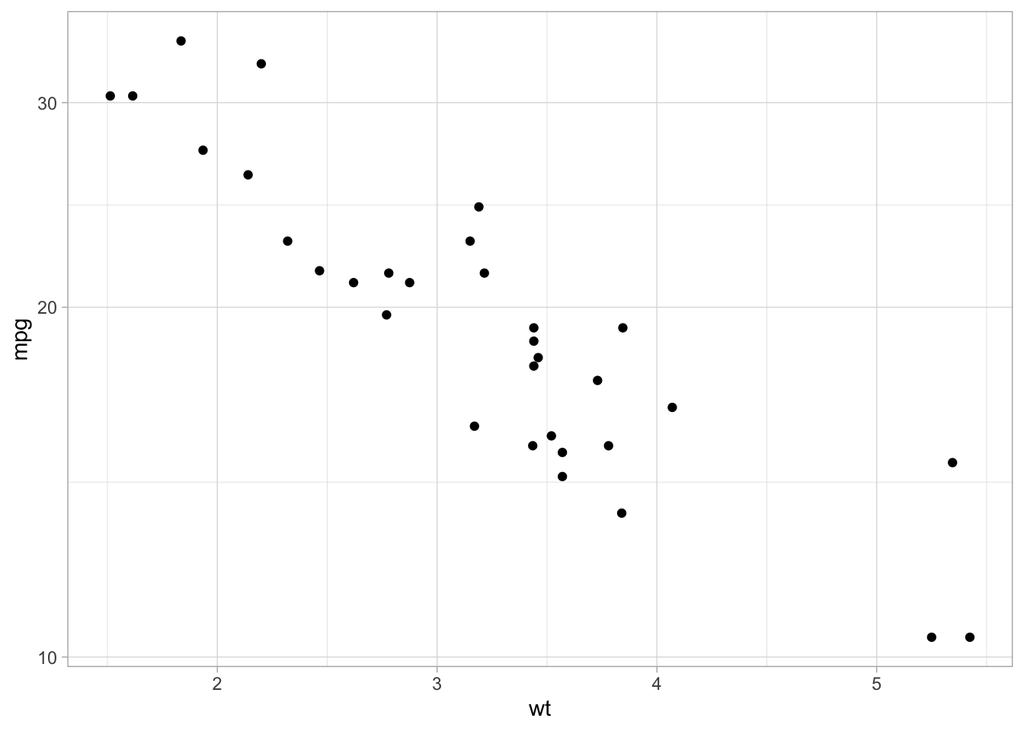

```r
ggplot(mtcars, aes(x = wt, y = mpg)) +
  geom_point() +
  scale_y_log10() +
  theme_light()
```

**Remember:**

- `aes()` maps variables to visual properties.
- `scale_*()` controls how those mappings are displayed.
- `theme()` controls non-data elements such as backgrounds, gridlines, and fonts.

### Example: Identify parts of the plot are produced by which part of command

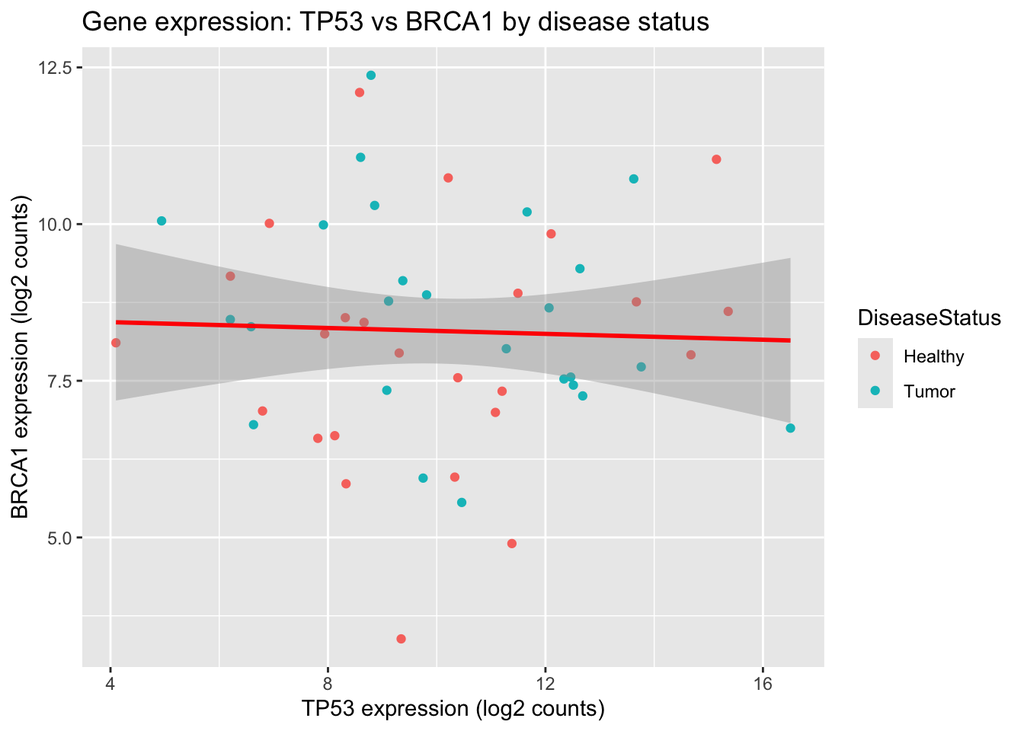

```r
set.seed(123)
molecular_data <- data.frame(
  TP53 = rnorm(50, mean = 10, sd = 3),
  BRCA1 = rnorm(50, mean = 8, sd = 2),
  DiseaseStatus = rep(c("Healthy", "Tumor"), each = 25)
)

p2 <- ggplot(molecular_data, aes(x = TP53, y = BRCA1, color = DiseaseStatus)) +
  geom_point() +
  geom_smooth(method = "lm", color = "red") +
  labs(title = "Gene expression: TP53 vs BRCA1 by disease status",
       x = "TP53 expression (log2 counts)",
       y = "BRCA1 expression (log2 counts)")

p2
```

For each plot element below, identify which part of the ggplot2 command produced it:

1. The scatter plot points colored by disease status
2. The red smoothing line (linear regression)
3. The main plot title
4. The x-axis label
5. The y-axis label
6. The specification of which genes are on the x and y axes
7. The plot panel background and gridlines

## Facets

### Example: Let’s build another graph

We want to see if there is any connection between expression of probe 1242_at and probe 1866_g_at in the leukemia dataset. We will create a graph with numerical x (1242_at expression) and y (1866_g_at expression) axes.

First let’s read in and combine the datasets.

```r
# Read data with fread for efficiency
data1 <- fread("http://hex.bioinfo.hr/~rosa/R_workshop/1242_at.leukemia.txt")
data2 <- fread("http://hex.bioinfo.hr/~rosa/R_workshop/1866_g_at.leukemia.txt")

# Rename the 'expression' columns by reference
setnames(data1, "expression", "expression_1242_at")
setnames(data2, "expression", "expression_1866_g_at")

# Perform an inner join on 'row.names' and 'stage' columns
data <- merge(data1, data2, by = c("V1", "stage"), all = FALSE)

# View the result
head(data)
```

| V1 | stage | expression_1242_at | expression_1866_g_at |
| --- | --- | --- | --- |
| 1005 | B2 | 6.594910 | 4.025540 |
| 1010 | B2 | 6.564573 | 4.315583 |
| 4006 | B1 | 6.696147 | 4.748316 |
| 4007 | B2 | 6.321552 | 4.503296 |
| 4008 | B1 | 6.588449 | 5.329210 |
| 4010 | B1 | 6.853832 | 4.136772 |

Now we want to make a scatterplot and see whether there is any connection between expression_1242_at (x axis) and expression_1866_g_at (y axis) in leukemia dataset.

**Hint:** You need to make a basic layer, define aesthetics and add a layer with the points.

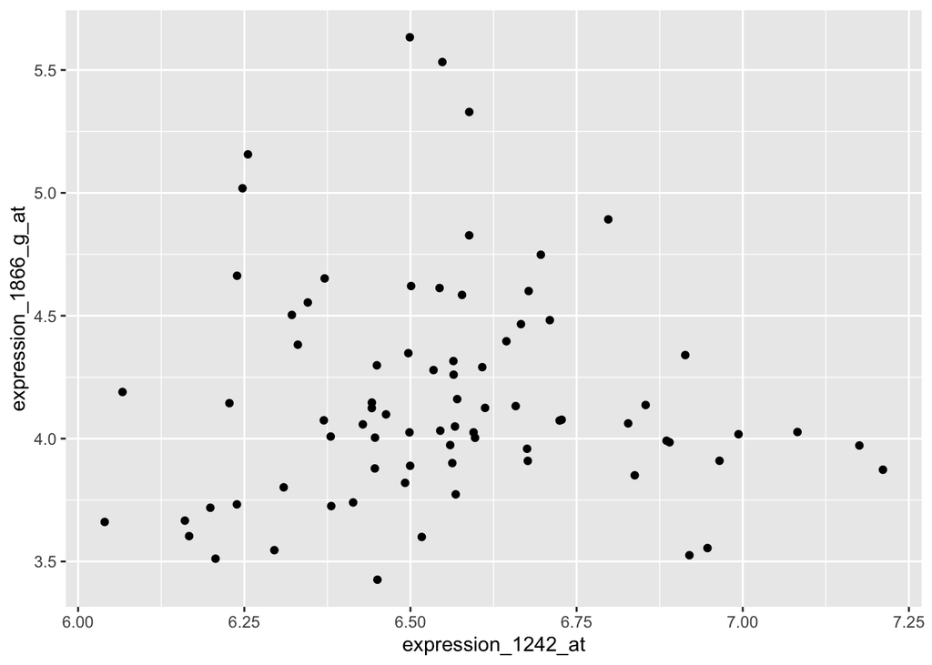

```r
# make a scatterplot with expression_1242_at on the x axis and expression_1866_g_at on the y axis

p <- ggplot(data, aes(x = expression_1242_at, y = expression_1866_g_at)) + geom_point()
p
```

This looks ok but now we would like for each stage to appear in its own graph. For this use facet_wrap(). Parameter to facet_wrap is the variable by which you would want to separate the graphs (~variable2). If you put ~variable2, then the graph will be separated into as many columns as there are levels in variable2. Lets separate our scatterplot to columns by “stage” variable.

**Hint:** You need to add a facet to the previous plot.

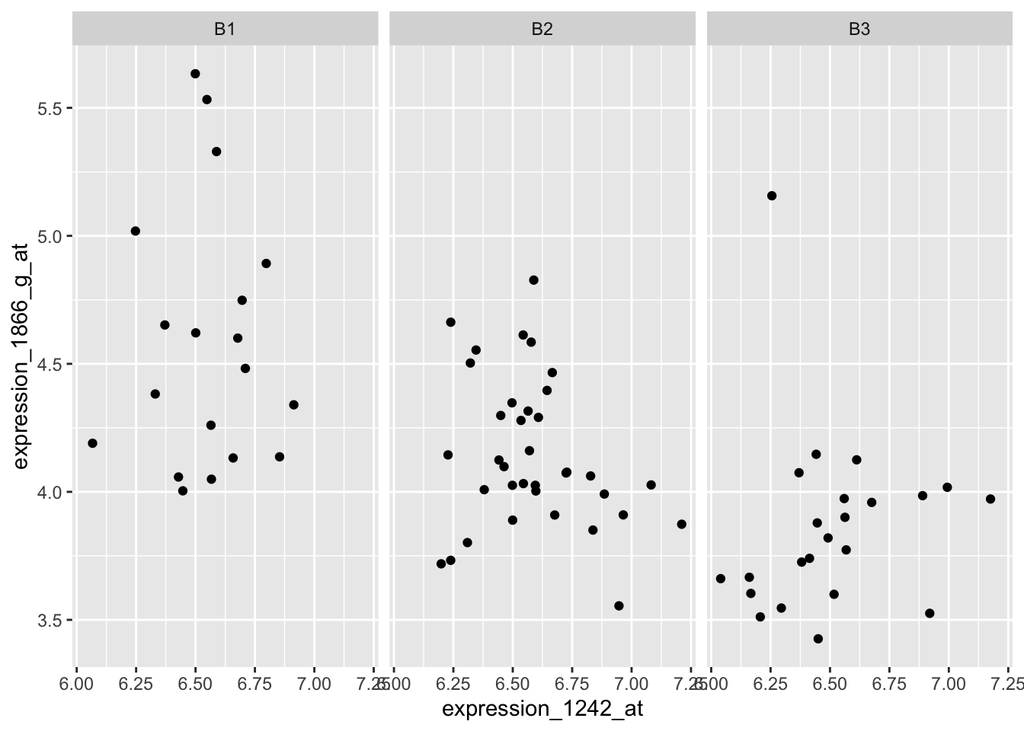

```r
# make a scatterplot with expression_1242_at on the x axis and expression_1866_g_at on the y axis

p <- ggplot(data, aes(x = expression_1242_at, y = expression_1866_g_at)) + geom_point() +facet_wrap(~stage)
p
```

- `facet_wrap()` is useful when splitting by one categorical variable.
- `facet_grid()` arranges plots in a grid according to two categorical variables.

## Statistics

Let’s do some exploratory analysis and add linear regression lines to the plot, to check whether the relationship between the expression values of the two probes is similar in all stages. We can check this by adding geom_smooth() to the plot.

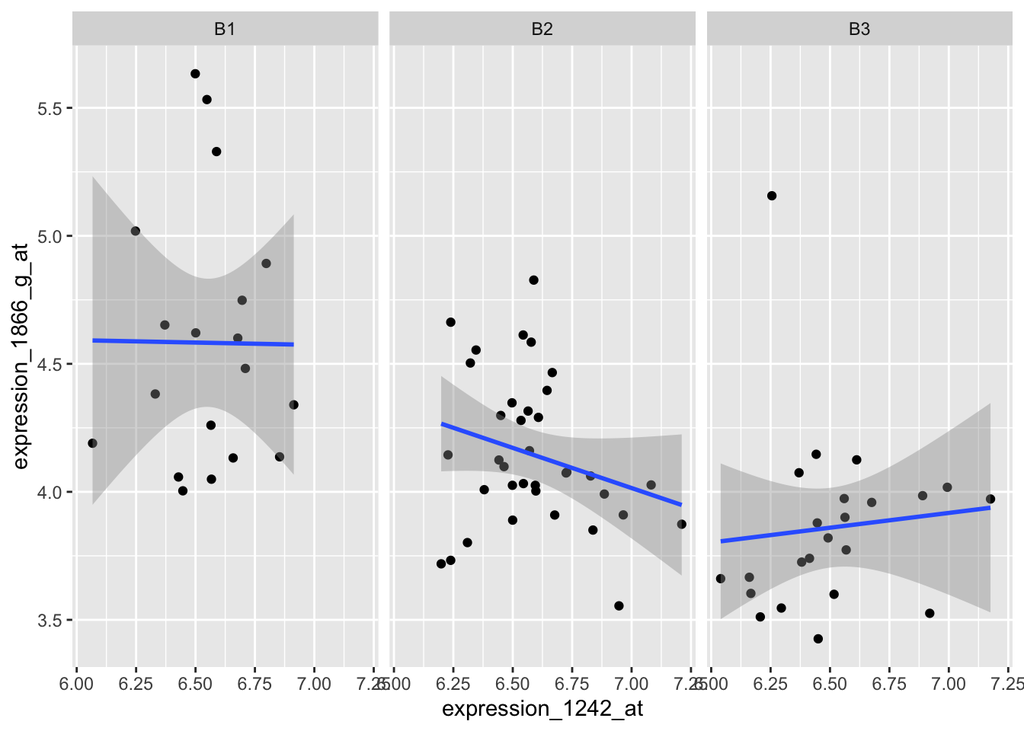

```r
# add linear regression lines to the plot with the facets


p <- ggplot(data, aes(x = expression_1242_at, y = expression_1866_g_at)) + geom_point() +facet_wrap(~stage) + geom_smooth(method = "lm")
p
```

**Hint:** You can check the available smoothing methods with ?geom_smooth.

```r
y <- c(18, 11, 16)
df_se <- data.frame(x = 1:3, y = y, se = c(1.2, 0.5, 1.0))

base <- ggplot(df_se, aes(x, y, ymin = y - se, ymax = y + se))
```

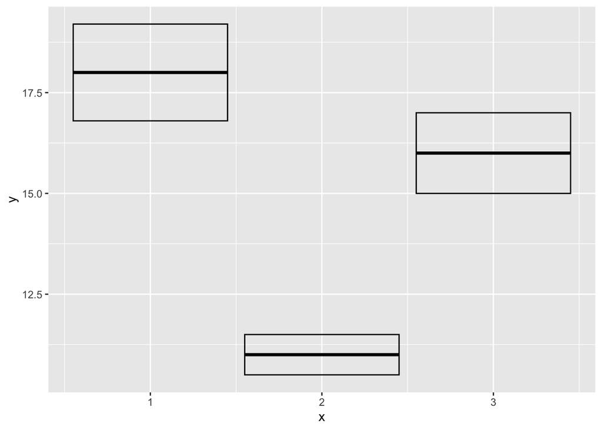

```r
base + geom_crossbar()
```

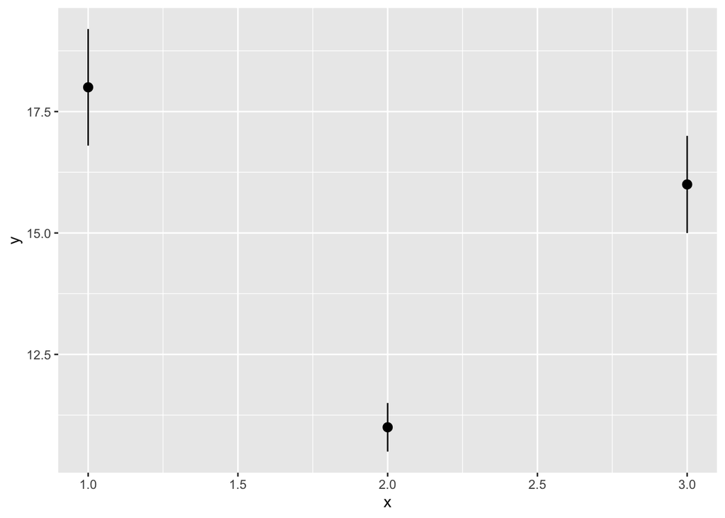

```r
base + geom_pointrange()
```

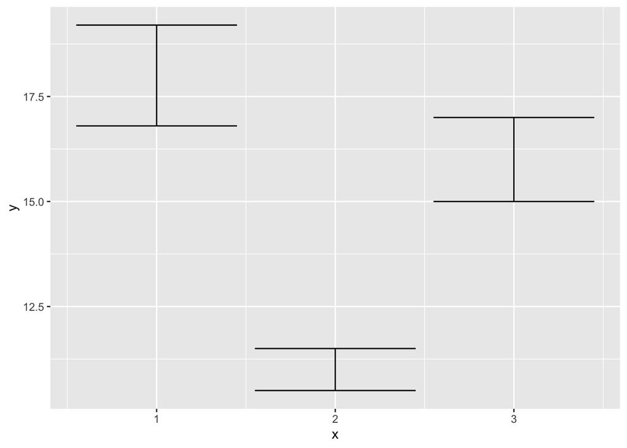

```r
base + geom_errorbar()
```

There are several R packages for adding statistical annotations to plots (particularly with ggplot2):

**ggpubr**: Adds correlation coefficients, p-values, and other statistics with functions like stat_cor() easily on ggplot2 plots. [ggpubr](https://rpkgs.datanovia.com/ggpubr/)

**ggpval**: Automatically performs statistical tests (t-tests, Wilcoxon, etc.) between groups and annotates p-values on ggplot2 plots. ggpval

**ggstatsplot**: Creates visually informative plots with statistical details, significance tests, and effect sizes included by default. [ggstatsplot](https://indrajeetpatil.github.io/ggstatsplot/)

**ggsignif**: Provides an easy way to add significance brackets to ggplot2 plot. [ggsignif](https://const-ae.github.io/ggsignif/)

Lets add a correlation coefficient to the scatterplot with expression_1242_at on the x axis and expression_1866_g_at on the y axis (with facets by stage).

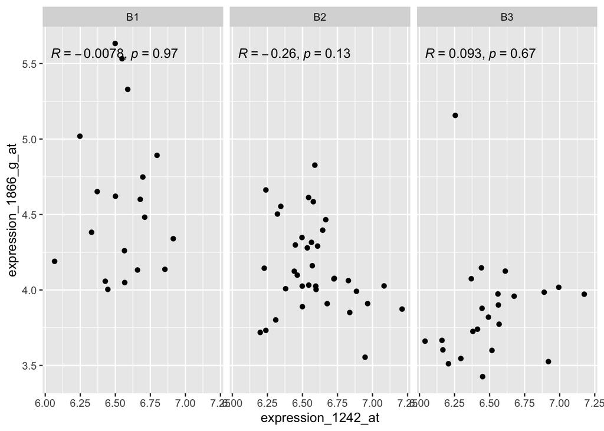

```r
library(ggpubr)
p <- ggplot(data, aes(x = expression_1242_at, y = expression_1866_g_at)) +
  geom_point() +
  facet_wrap(~stage) +
  stat_cor(method = "pearson")
p
```

## Themes

Many visual aspects of the plots can be adjusted using theme() and scale_X_Y() There are various themes already available, but they can also be tweaked

**ggpubr** package let’s you produce publication-ready plots, with various themes, adding statistics to plots and combining various ggplot objects into one figure. https://rpkgs.datanovia.com/ggpubr/

**ggsci** package includes scientific journal and Sci-Fi themed color palettes for ggplot2 https://cran.r-project.org/web/packages/ggsci/vignettes/ggsci.html

We can make our scatterplot a bit nicer.

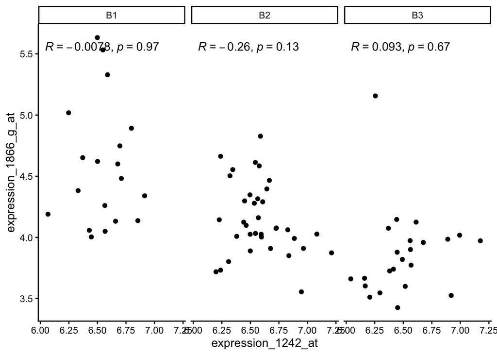

```r
p <- ggplot(data, aes(x = expression_1242_at, y = expression_1866_g_at)) +
  geom_point() +
  facet_wrap(~stage) +
  stat_cor(method = "pearson")+
  theme_classic2()
p
```

We can save our plots using the *ggsave()* function. The function saves a single ggplot object to a file (PNG, PDF, SVG, TIFF, etc.) with customizable size, resolution, and format based on the filename extension.

```r
ggsave("my.first.plot.png", plot = p, width = 12, height = 7)
```

Once you find the best way to visualize the data, you can simply change the dataset of the ggplot object using the ggplot **%+%** operator

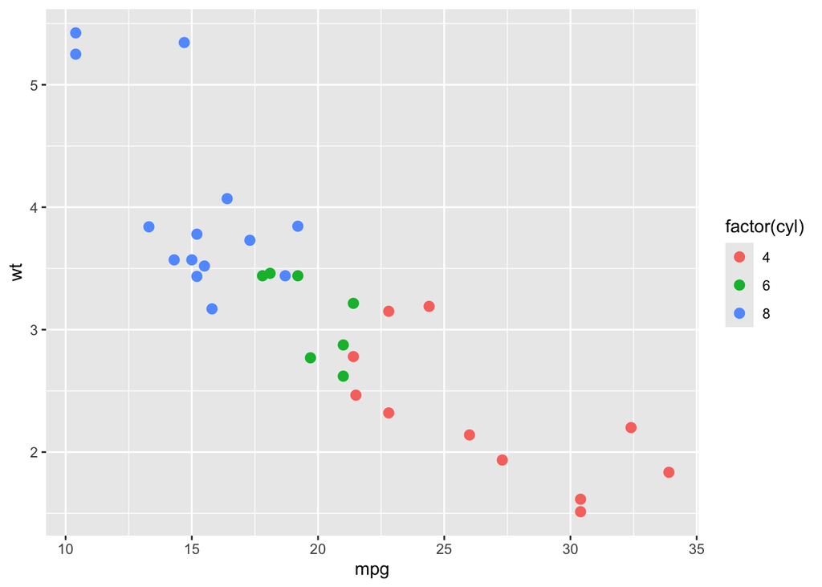

```r
p <- ggplot(mtcars, aes(mpg, wt, color=factor(cyl))) +
  geom_point(shape=20, size=4)
print(p)
```

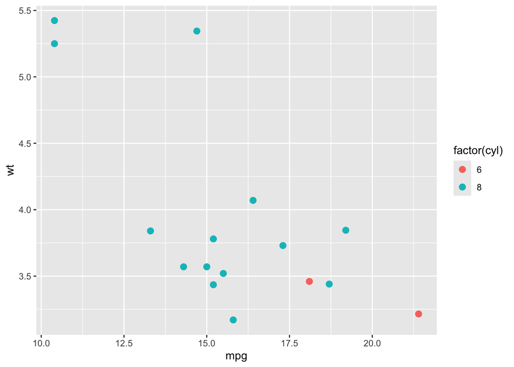

```r
p2<-p %+% mtcars[mtcars$disp>200,]
print(p2)
```

For more information and help with making graphs see the [R Graphics Cookbook](https://r-graphics.org/)

## Exercises

Use the datasets `qpcr_ddCt` and `df` created during the lecture to complete the following exercises.

### Exercise 1. Comparison of TP53 and MYC expression

Using the `qpcr_ddCt` dataset, visualize the relative expression of TP53 and MYC in control and treated samples.

1. Create a boxplot showing relative expression (`fold_change`) for TP53 and MYC.
2. Color the boxes according to experimental condition.
3. Add individual sample measurements to the plot.
4. Add an appropriate title, axis labels, and a theme.

**Hint:** Use `geom_boxplot()`, `geom_jitter()`, and `fill` inside `aes()`. You can select the two genes using `Gene %in% c("TP53", "MYC")`.

```r
# Your code here
```

### Exercise 2. Comparison of ΔCt values across conditions

Using the `qpcr_ddCt` dataset, compare normalized Ct values between control and treated samples.

1. Create a boxplot of `deltaCt` values for each experimental condition.
2. Color the boxes by condition.
3. Use `facet_wrap()` to display each gene in a separate panel.
4. Overlay individual measurements.
5. Add informative axis labels and a theme.

**Hint:** Map `Condition` to the x-axis, `deltaCt` to the y-axis, and use `facet_wrap(~Gene)`.

```r
# Your code here
```

### Exercise 3. Visualizing mutation frequencies

Using the simulated dataset `df`, investigate whether mutation frequencies differ between treatment groups.

1. Create a barplot showing the number of WT and mutated samples in each treatment group.
2. Modify the graph to show proportions rather than absolute counts.
3. Change the fill colors using `scale_fill_manual()`.
4. Add informative labels and use a minimal theme.

**Hint:** Use `geom_bar(position = "dodge")` for counts and `geom_bar(position = "fill")` for proportions.

```r
# Your code here
```

**Question:** When would you choose to show absolute counts rather than proportions? What information is lost when using a 100% stacked barplot?

### Exercise 4. Summarizing and visualizing gene expression

Using the simulated dataset `df`, compare the average expression of `Gene1` between control and treated samples.

1. Calculate the mean and standard deviation of `Gene1_expr` for each treatment group.
2. Create a barplot showing mean expression.
3. Add error bars representing ±1 standard deviation.
4. Overlay individual observations on the graph.
5. Change the theme and save the resulting graph as a PNG file.

**Hint:** Use `data.table` or `dplyr` to calculate summary statistics, `geom_col()` for the means, `geom_errorbar()` for standard deviations, and `ggsave()` to save the graph.

```r
# Your code here
```

**Question:** What is the difference between standard deviation (SD) and standard error of the mean (SEM)? Which one is more appropriate for showing the variability of individual samples?